# Project 2

Mehal Agrawal

2023-11-06

# **Introduction**

This dataset analyzes the airplane landings at SFO International Airport. The data has been obtained from DataSF, a website that tracks different types of data in San Franscisco. This data is publicly available to help enhance decision making. The dataset was received from [here](https://data.sfgov.org/Transportation/Air-Traffic-Landings-Statistics/fpux-q53t). I picked this dataset because I love to travel and have been to SFO many times as it is my local airport. I was interested in analyzing the air traffic at SFO and gaining more insight about the airport itself.

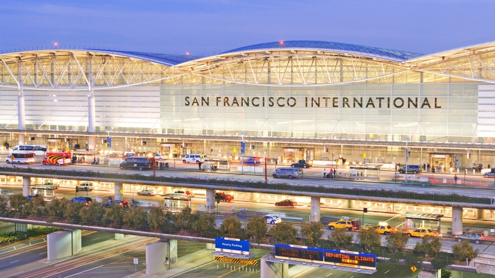

Bills, Terry. “San Francisco Airport’s Dynamic Twin Has Transformed Operations.” Esri, 21 Oct. 2021, esri.com/about/newsroom/blog/san-francisco-airport-bim-gis-processes/. Accessed 07 Nov. 2023.

# **Data Preparation**

I downloaded the csv file and then imported it into the Rmarkdown. As for processing, the main step I had to take was renaming the variables so that there were no spaces in them. I made 3 new variables. The first one was “Total_Landed_Weight_In_Millions.” I made this variable because the orginial variable had values that were very big and would be harder to handle later on in terms of graphing and analyzing. The second variable I made was “Continent.” I made this varaible because my report investigates the relationship between the aircraft manufacturer and continent. The last variable I created was a month variable which is later investigated in this report. Challenges I faced while preparing my data was the amoutn of data there is in the data set. I had to take time to understand each variable and how it functions in the data set. In terms of NA values, I dropped the rows that contained them. This is because I would not be able to analyze these rows. My data set now has 16,115 observations with 16 variables.

# **Variable Descriptions**

[output not shown]

[output cut: 41 more lines]

[output not shown]

# **Univariate Analyses**

Univariate Analyses: Choose at least 4 of your variables and create univariate graphs to display them. Provide a brief description of the distribution, including more than one relevant descriptive statistic, to go along with each graph.

Questions: what statistics can you describe for a bar chart do I have to drop variables i am not using because each row is unqiue because of that

### Graph 1

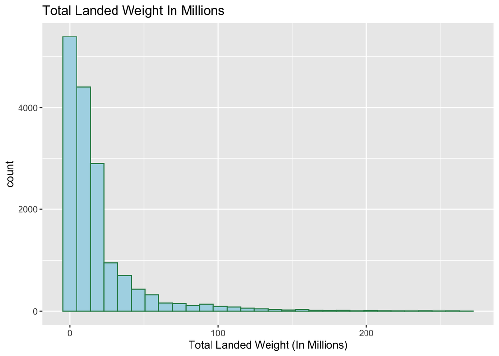

This graph displayed a histogram of the Total Landed Weight In Millions for each plane type. The histogram is skewed right with a mean of 18.4. The maximum total weight landed is 267.3 and the minimum total landed weight in millions is 0.01.

### Graph 2

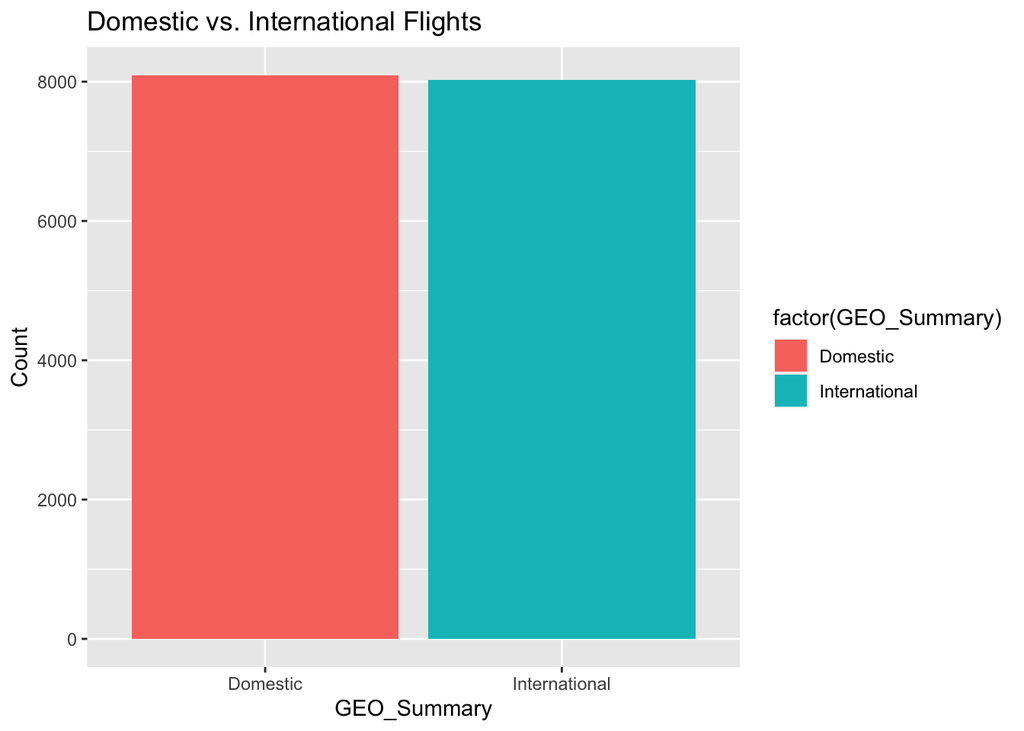

This bar graph shows the numebr of planes that arrived from a domestic location and the number of planes that arrived from an international location. 8092 arrived from a domestic location or 50.2% of planes. 8023 or 49.8% of planes arrived from an international location.

### Graph 3

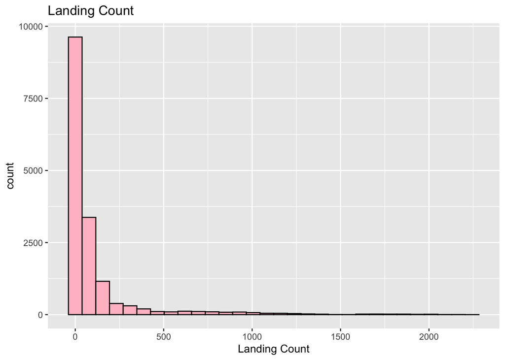

This histogram shows the landing count of each plane type at SFO Airport. It is skewed right with a mean of 112.55. The maximum number of times a plane type landed is 2245.

### Graph 4

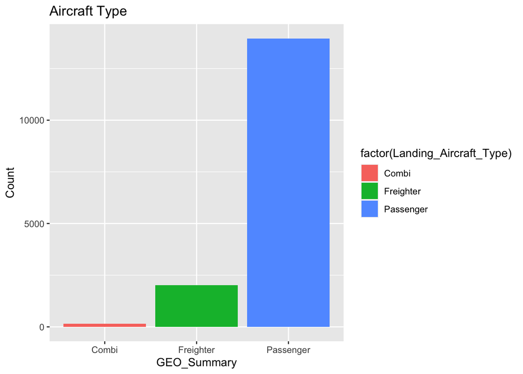

# **Multivariate Analyses**

Multivariate Analyses: Create at least 4 multivariate (2 or more variables) graphs to display the relationships among your variables of interest. Provide a brief description of what your plots show, including one or more bivariate descriptive statistics.

### Graph 1

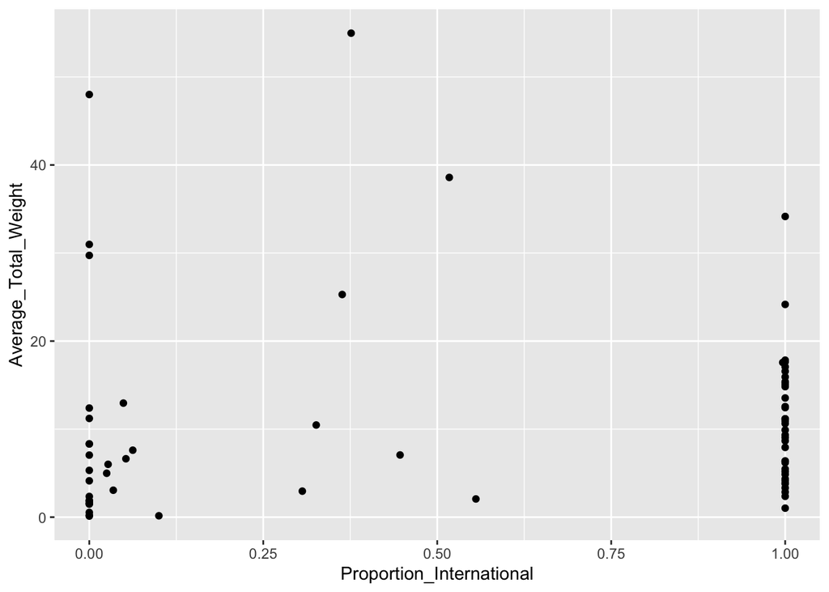

```
## # A tibble: 74 × 2
##    Published_Airline  `round(mean(Total_Landed_Weight_In_Millions), 2)`
##    <chr>                                                          <dbl>
##  1 ABX Air                                                         8.33
##  2 ATA Airlines                                                    6.63
##  3 Aer Lingus                                                      7.92
##  4 Aeromexico                                                      6.19
##  5 Air Berlin                                                      3.88
##  6 Air Canada                                                      6.31
##  7 Air Cargo Carriers                                              0.54
##  8 Air China                                                      13.5
##  9 Air France                                                     11.2
## 10 Air India Limited                                               6.39
## # ℹ 64 more rows
```

### Graph 2

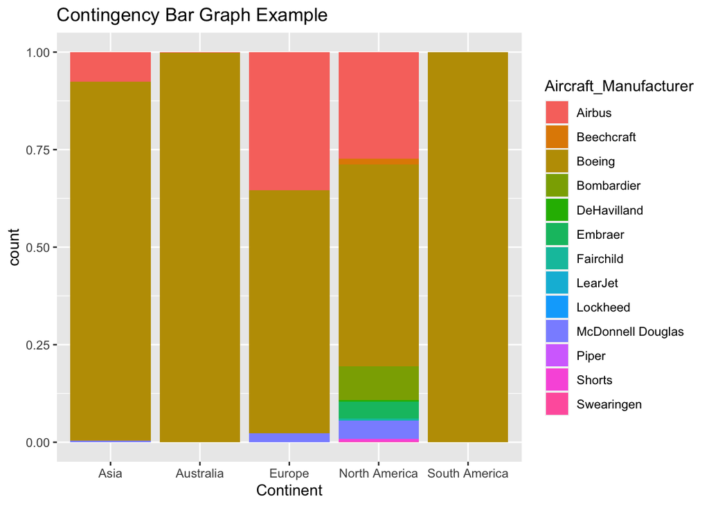

### Graph 3

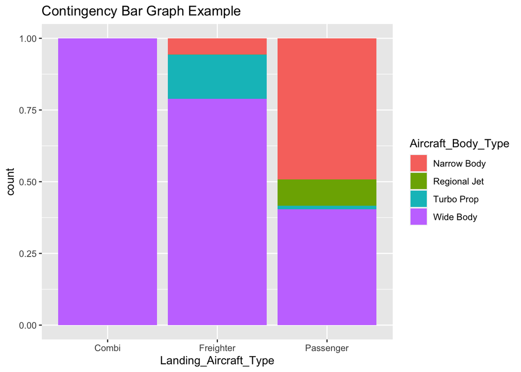

### Graph 4

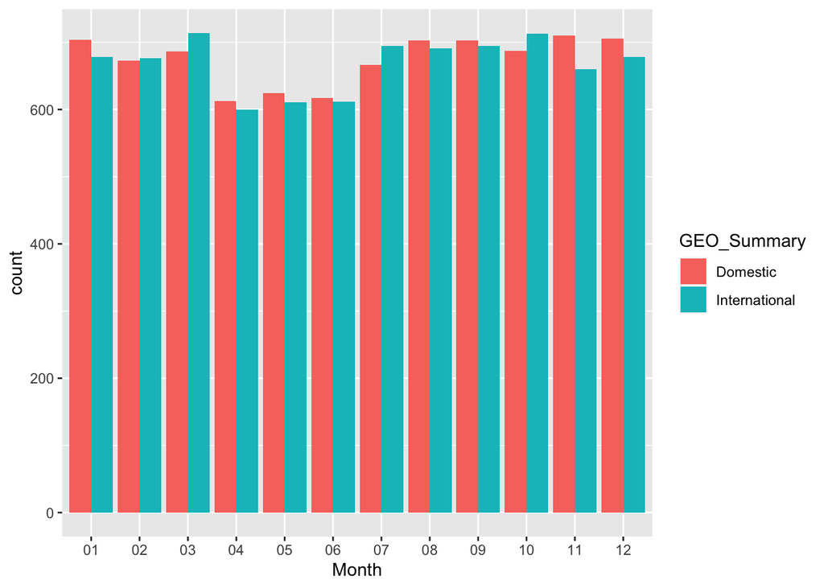